# Comparison of Repair and Replacement in patients with Active Infective Endocarditis in Native Mitral Valve

Sun Kim

2021 6 12

# Active IE

## Study population

[interactive chart not shown]

# Prematch

## Tables

### Repair vs. Replacement

#### Baseline Table

Repair

Replacement

Total

p

(N=87)

(N=131)

(N=218)

Male

51 (58.6%)

75 (57.3%)

126 (57.8%)

0.952

Age

43.7 ± 16.1

50.5 ± 16.9

47.8 ± 16.9

0.003

Height

167.2 ± 8.2

164.7 ± 9.1

165.7 ± 8.8

0.044

Weight

58.7 ± 10.8

59.9 ± 11.5

59.4 ± 11.2

0.426

BMI

21.0 ± 3.4

22.0 ± 3.4

21.6 ± 3.4

0.029

Dyspnea

14 (16.1%)

36 (27.5%)

50 (22.9%)

0.073

Fever

75 (86.2%)

110 (84.0%)

185 (84.9%)

0.796

Chillis

40 (46.0%)

59 (45.0%)

99 (45.4%)

1.000

Myalgia

35 (40.2%)

45 (34.4%)

80 (36.7%)

0.460

Fatigue

5 ( 5.7%)

14 (10.7%)

19 ( 8.7%)

0.307

Generalweakness

24 (27.6%)

56 (42.7%)

80 (36.7%)

0.033

Embolism

49 (56.3%)

72 (55.0%)

121 (55.5%)

0.953

Hypertension

17 (19.5%)

39 (29.8%)

56 (25.7%)

0.125

Diabetes

7 ( 8.0%)

20 (15.3%)

27 (12.4%)

0.169

CAD

5 ( 5.7%)

6 ( 4.6%)

11 ( 5.0%)

0.758

CVA

4 ( 4.6%)

11 ( 8.4%)

15 ( 6.9%)

0.417

CKD

7 ( 8.0%)

12 ( 9.2%)

19 ( 8.7%)

0.968

Dialysis

5 ( 5.7%)

9 ( 6.9%)

14 ( 6.4%)

0.961

Smoking

26 (29.9%)

46 (35.1%)

72 (33.0%)

0.511

Malignancy

5 ( 5.7%)

15 (11.5%)

20 ( 9.2%)

0.234

Obesity

9 (10.3%)

25 (19.4%)

34 (15.7%)

0.110

PreviousOHS

0 ( 0.0%)

2 ( 1.5%)

2 ( 0.9%)

0.518

Bloodculture(+)

66 (75.9%)

113 (86.3%)

179 (82.1%)

0.075

WBC

9.0 ± 4.6

11.2 ± 5.9

10.3 ± 5.5

0.003

Hemoglobin

10.7 ± 1.6

10.3 ± 1.7

10.5 ± 1.7

0.052

Platelet

248.4 ± 115.8

234.3 ± 112.7

239.9 ± 113.9

0.371

PT (INR)

1.1 ± 0.2

1.2 ± 0.2

1.2 ± 0.2

0.283

Albumin

3.4 ± 0.6

3.1 ± 0.5

3.3 ± 0.6

< 0.001

Total Bilirubin

0.8 ± 0.9

0.8 ± 1.2

0.8 ± 1.1

0.753

AST

28.9 ± 18.0

48.1 ± 181.4

40.5 ± 141.5

0.233

ALT

28.6 ± 23.3

42.6 ± 116.4

37.0 ± 91.7

0.184

BUN

13.8 ± 9.8

18.3 ± 16.8

16.5 ± 14.6

0.014

Creatinine

1.2 ± 1.4

1.6 ± 2.2

1.4 ± 1.9

0.110

HbA1c

5.7 ± 0.7

6.0 ± 1.1

5.9 ± 0.9

0.157

NT-proBNP

3488.3 ± 8774.1

6026.2 ± 9663.7

5041.8 ± 9383.8

0.091

Segmented neutrophil

71.3 ± 11.4

75.3 ± 10.9

73.8 ± 11.3

0.010

CRP

5.6 ± 6.2

6.9 ± 6.7

6.3 ± 6.5

0.164

Procalcitonin

3.0 ± 5.8

20.7 ± 71.6

13.0 ± 54.5

0.085

Ix_CHF

39 (44.8%)

77 (58.8%)

116 (53.2%)

0.060

Ix_infection

12 (13.8%)

11 ( 8.4%)

23 (10.6%)

0.296

Ix_vegetation

71 (81.6%)

111 (84.7%)

182 (83.5%)

0.673

Onset-to-Surgery duration

23.3 ± 17.4

25.5 ± 25.3

24.6 ± 22.4

0.462

Antibiotics-to-Surgery duration

8.7 ± 10.5

8.0 ± 9.5

8.3 ± 9.9

0.589

prev_MV_Op

- FALSE

87 (100.0%)

131 (100.0%)

218 (100.0%)

MS

0.082

- no

87 (100.0%)

119 (90.8%)

206 (94.5%)

- minimal

0 ( 0.0%)

0 ( 0.0%)

0 ( 0.0%)

- minimal-to-mild

0 ( 0.0%)

0 ( 0.0%)

0 ( 0.0%)

- mild

0 ( 0.0%)

1 ( 0.8%)

1 ( 0.5%)

- mild-to-moderate

0 ( 0.0%)

1 ( 0.8%)

1 ( 0.5%)

- moderate

0 ( 0.0%)

3 ( 2.3%)

3 ( 1.4%)

- moderate-to-severe

0 ( 0.0%)

2 ( 1.5%)

2 ( 0.9%)

- severe

0 ( 0.0%)

5 ( 3.8%)

5 ( 2.3%)

MR

0.091

- no

6 ( 6.9%)

15 (11.5%)

21 ( 9.6%)

- minimal

6 ( 6.9%)

2 ( 1.5%)

8 ( 3.7%)

- minimal-to-mild

1 ( 1.1%)

2 ( 1.5%)

3 ( 1.4%)

- mild

13 (14.9%)

9 ( 6.9%)

22 (10.1%)

- mild-to-moderate

4 ( 4.6%)

4 ( 3.1%)

8 ( 3.7%)

- moderate

14 (16.1%)

15 (11.5%)

29 (13.3%)

- moderate-to-severe

8 ( 9.2%)

13 ( 9.9%)

21 ( 9.6%)

- severe

35 (40.2%)

71 (54.2%)

106 (48.6%)

MR>=moderate

57 (65.5%)

99 (75.6%)

156 (71.6%)

0.145

Annularreconstruction

8 ( 9.2%)

31 (23.7%)

39 (17.9%)

0.011

prev_AV_Op

- FALSE

87 (100.0%)

131 (100.0%)

218 (100.0%)

AVIE

5 ( 5.7%)

4 ( 3.1%)

9 ( 4.1%)

0.489

AS

1.000

- no

87 (100.0%)

131 (100.0%)

218 (100.0%)

- minimal

0 ( 0.0%)

0 ( 0.0%)

0 ( 0.0%)

- minimal-to-mild

0 ( 0.0%)

0 ( 0.0%)

0 ( 0.0%)

- mild

0 ( 0.0%)

0 ( 0.0%)

0 ( 0.0%)

- mild-to-moderate

0 ( 0.0%)

0 ( 0.0%)

0 ( 0.0%)

- moderate

0 ( 0.0%)

0 ( 0.0%)

0 ( 0.0%)

- moderate-to-severe

0 ( 0.0%)

0 ( 0.0%)

0 ( 0.0%)

- severe

0 ( 0.0%)

0 ( 0.0%)

0 ( 0.0%)

AR

0.277

- no

82 (94.3%)

128 (97.7%)

210 (96.3%)

- minimal

1 ( 1.1%)

0 ( 0.0%)

1 ( 0.5%)

- minimal-to-mild

0 ( 0.0%)

0 ( 0.0%)

0 ( 0.0%)

- mild

3 ( 3.4%)

2 ( 1.5%)

5 ( 2.3%)

- mild-to-moderate

0 ( 0.0%)

0 ( 0.0%)

0 ( 0.0%)

- moderate

0 ( 0.0%)

1 ( 0.8%)

1 ( 0.5%)

- moderate-to-severe

0 ( 0.0%)

0 ( 0.0%)

0 ( 0.0%)

- severe

1 ( 1.1%)

0 ( 0.0%)

1 ( 0.5%)

AR>=moderate

1 ( 1.1%)

1 ( 0.8%)

2 ( 0.9%)

1.000

ConcomitantAVOp

8 ( 9.2%)

7 ( 5.3%)

15 ( 6.9%)

0.408

prev_TV_Op

- FALSE

87 (100.0%)

131 (100.0%)

218 (100.0%)

TV_IE

2 ( 2.3%)

1 ( 0.8%)

3 ( 1.4%)

0.565

TS

1.000

- no

87 (100.0%)

131 (100.0%)

218 (100.0%)

- minimal

0 ( 0.0%)

0 ( 0.0%)

0 ( 0.0%)

- minimal-to-mild

0 ( 0.0%)

0 ( 0.0%)

0 ( 0.0%)

- mild

0 ( 0.0%)

0 ( 0.0%)

0 ( 0.0%)

- mild-to-moderate

0 ( 0.0%)

0 ( 0.0%)

0 ( 0.0%)

- moderate

0 ( 0.0%)

0 ( 0.0%)

0 ( 0.0%)

- moderate-to-severe

0 ( 0.0%)

0 ( 0.0%)

0 ( 0.0%)

- severe

0 ( 0.0%)

0 ( 0.0%)

0 ( 0.0%)

TR

0.148

- no

82 (94.3%)

108 (82.4%)

190 (87.2%)

- minimal

0 ( 0.0%)

1 ( 0.8%)

1 ( 0.5%)

- minimal-to-mild

1 ( 1.1%)

1 ( 0.8%)

2 ( 0.9%)

- mild

2 ( 2.3%)

6 ( 4.6%)

8 ( 3.7%)

- mild-to-moderate

2 ( 2.3%)

7 ( 5.3%)

9 ( 4.1%)

- moderate

0 ( 0.0%)

6 ( 4.6%)

6 ( 2.8%)

- moderate-to-severe

0 ( 0.0%)

0 ( 0.0%)

0 ( 0.0%)

- severe

0 ( 0.0%)

2 ( 1.5%)

2 ( 0.9%)

TR>=moderate

0 ( 0.0%)

8 ( 6.1%)

8 ( 3.7%)

0.023

ConcomitantTVOp

4 ( 4.6%)

19 (14.5%)

23 (10.6%)

0.035

Concomitantprocedure

15 (17.2%)

26 (19.8%)

41 (18.8%)

0.760

CABG

2 ( 2.3%)

8 ( 6.1%)

10 ( 4.6%)

0.322

Maze

0 ( 0.0%)

4 ( 3.1%)

4 ( 1.8%)

0.152

Aortasurgery

0 ( 0.0%)

2 ( 1.5%)

2 ( 0.9%)

0.518

CPB time

110.8 ± 54.0

129.8 ± 49.9

122.1 ± 52.3

0.009

ACC time

83.5 ± 45.9

102.6 ± 42.1

94.9 ± 44.6

0.002

Nasal temperature

29.8 ± 1.8

29.1 ± 2.5

29.4 ± 2.3

0.010

Rectal temperature

31.0 ± 1.7

30.6 ± 2.1

30.8 ± 2.0

0.104

Death

8 ( 9.2%)

29 (22.1%)

37 (17.0%)

0.021

Earlymortality

2 ( 2.3%)

4 ( 3.1%)

6 ( 2.8%)

1.000

In-hospitalmortality

2 ( 2.3%)

4 ( 3.1%)

6 ( 2.8%)

1.000

Recurrence

1 ( 1.1%)

7 ( 5.3%)

8 ( 3.7%)

0.149

Reoperationd/trecurrence

1 ( 1.1%)

6 ( 4.6%)

7 ( 3.2%)

0.247

Valve-relatedReopartion

3 ( 3.4%)

3 ( 2.3%)

6 ( 2.8%)

0.685

Bleeding

1 ( 1.1%)

23 (17.6%)

24 (11.0%)

< 0.001

Majorbleeding

1 ( 1.1%)

20 (15.3%)

21 ( 9.6%)

0.001

Minorbleeding

0 ( 0.0%)

3 ( 2.3%)

3 ( 1.4%)

0.277

Thromboembolism

1 ( 1.1%)

7 ( 5.3%)

8 ( 3.7%)

0.149

Majorthromboembolism

1 ( 1.1%)

5 ( 3.8%)

6 ( 2.8%)

0.406

Minorthromboembolism

0 ( 0.0%)

2 ( 1.5%)

2 ( 0.9%)

0.518

#### SMD Table

| variable | smd |
| --- | --- |
| Info_Male | -0.0277 |
| Info_Age | 0.4128 |
| Baseline_Ht | -0.2830 |
| Baseline_Wt | 0.1115 |
| Baseline_BMI | 0.3050 |
| Symptom_dyspnea | -0.2786 |
| Symptom_fever | -0.0628 |
| Symptom_chills | -0.0189 |
| Symptom_myalgia | -0.1218 |
| Symptom_fatigue | -0.1806 |
| Symptom_GW | 0.3216 |
| IE_embolism | 0.0274 |
| PMH_HTN | -0.2391 |
| PMH_DM | -0.2265 |
| PMH_CAD | 0.0528 |
| PMH_CVA | -0.1546 |
| PMH_CKD | -0.0397 |
| PMH_dialysis | -0.0462 |
| PMH_Smoking | 0.1118 |
| PMH_Malignancy | -0.2045 |
| PMH_Obesity | NA |
| PMH_prev.OHS | -0.1761 |
| IE_culture | 0.2677 |
| Lab_BL2011 | 0.4079 |
| Lab_BL2013 | -0.2714 |
| Lab_BL2016 | -0.1236 |
| Lab_BL211103 | 0.1521 |
| Lab_BL3112 | -0.4894 |
| Lab_BL3114 | 0.0425 |
| Lab_BL3115 | 0.1483 |
| Lab_BL3116 | 0.1665 |
| Lab_BL3119 | 0.3247 |
| Lab_BL3120 | 0.2116 |
| Lab_BL3164 | 0.2518 |
| Lab_BL3982 | 0.2750 |
| Lab_BL201806 | 0.3578 |
| Lab_BL3140 | 0.1947 |
| Lab_BL5044 | 0.3488 |
| Op_Ix_HF | 0.2820 |
| Op_Ix_uncontrolled_infection | 0.1725 |
| Op_Ix_Embolism_vegetation | -0.0836 |
| Duration_Onset2Op | 0.0982 |
| Duration_Anti2Op | -0.0741 |
| Mitral_prev_MV_Op | NA |
| Mitral_MS | NA |
| Mitral_MR | NA |
| MR_gr_mod | 0.2219 |
| Mitral_annular_recon | -0.3981 |
| Aortic_Prev_AV_Op | NA |
| Aortic_IE_lesion | 0.1316 |
| Aortic_AS | NA |
| Aortic_AR | NA |
| AR_gr_mod | 0.0397 |
| Aortic_Concomittant_AV_Op | 0.1488 |
| Tricuspid_Prev_TV_Op | NA |
| Tricuspid_IE_lesion | 0.1253 |
| Tricuspid_TS | NA |
| Tricuspid_TR | NA |
| TR_gr_mod | 0.3607 |
| Tricuspid_Concomittant_TV_Op | 0.3419 |
| Concomitant_other_procedure | -0.0671 |
| Concomitant_CABG | -0.1906 |
| Concomitant_maze | -0.2510 |
| Concomitant_aorta | -0.1761 |
| CPB_CPB_time | 0.3658 |
| CPB_ACC_time | 0.4323 |
| CPB_N_BT | -0.3500 |
| CPB_R_BT | -0.2320 |
| O_Survival_Death | -0.3618 |
| O_Survival_EM | -0.0468 |
| O_Survival_IHM | -0.0468 |
| O_Recurrence_Recur | -0.2383 |
| O_Recurrence_ReOp | -0.2068 |
| O_Valve_ReOp | 0.0694 |
| O_Valve_Bleeding | -0.5873 |
| O_Valve_B_major | -0.5322 |
| O_Valve_B_minor | -0.2165 |
| O_Valve_Embolism | -0.2383 |
| O_Valve_E_major | -0.1720 |
| O_Valve_E_minor | -0.1761 |

### MVR - Tissue vs. Mechanical

|  | Tissue | Mechanical | p |  |
| --- | --- | --- | --- | --- |
|  | (N=55) | (N=76) |  |  |
| Male | 26 (47.3%) | 49 (64.5%) |  | 0.074 |
| Age | 59.3 ± 17.6 | 44.1 ± 13.2 | < 0.001 |  |
| Death | 19 (34.5%) | 10 (13.2%) | 0.007 |  |
| Earlymortality | 2 ( 3.6%) | 2 ( 2.6%) | 1.000 |  |
| In-hospitalmortality | 2 ( 3.6%) | 2 ( 2.6%) | 1.000 |  |
| Recurrence | 4 ( 7.3%) | 3 ( 3.9%) | 0.453 |  |
| Reoperationd/trecurrence | 3 ( 5.5%) | 3 ( 3.9%) | 0.695 |  |
| Valve-relatedReopartion | 2 ( 3.6%) | 1 ( 1.3%) | 0.572 |  |
| Bleeding | 5 ( 9.1%) | 18 (23.7%) | 0.053 |  |
| Majorbleeding | 4 ( 7.3%) | 16 (21.1%) | 0.055 |  |
| Minorbleeding | 1 ( 1.8%) | 2 ( 2.6%) | 1.000 |  |
| Thromboembolism | 1 ( 1.8%) | 6 ( 7.9%) | 0.238 |  |
| Majorthromboembolism | 0 ( 0.0%) | 5 ( 6.6%) | 0.074 |  |
| Minorthromboembolism | 1 ( 1.8%) | 1 ( 1.3%) | 1.000 |  |

### Microorganisms in Active IE

| Organisms | Total (N=218) |
| --- | --- |
| Streptococci | 86 |
| MSSA | 38 |
| MRSA | 18 |
| Enterococci | 11 |
| HACEK | 6 |
| G(-) bacilli | 5 |
| CoNS | 4 |
| Polymicrobial | 4 |
| Fungi | 3 |
| Others | 4 |
| Culture-negative | 39 |

## Figures

### Survival - Repair vs. Replacment

Median follow up duration : 55.49 months

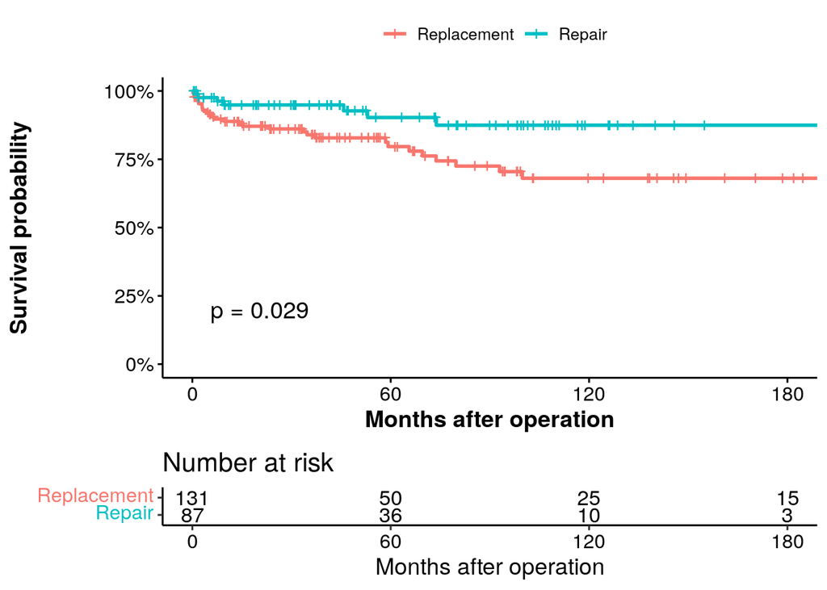

| strata | Month 60 | Month 120 | Month 180 |
| --- | --- | --- | --- |
| Overall | 83.8 ± 2.9 % | 75.5 ± 4.0 % | 75.5 ± 4.0 % |
| strata=FALSE | 79.6 ± 4.1 % | 68.0 ± 5.6 % | 68.0 ± 5.6 % |
| strata=TRUE | 90.3 ± 4.0 % | 87.5 ± 4.7 % | 87.5 ± 4.7 % |

### Composite Endpoint - Repair vs. Replacment

Median follow up duration : 53.16 months

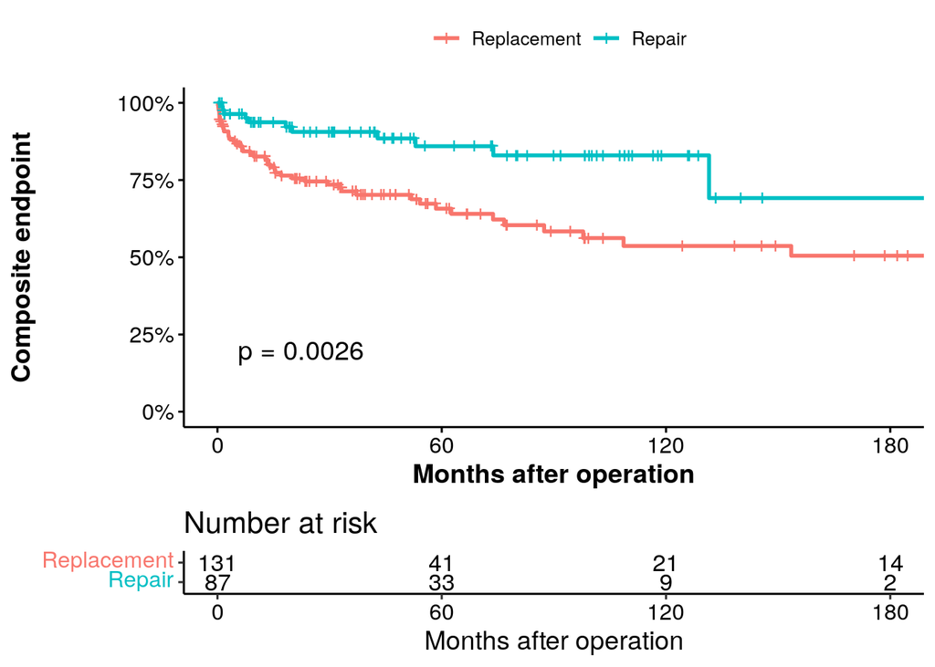

| strata | Month 60 | Month 120 | Month 180 |
| --- | --- | --- | --- |
| Overall | 73.5 ± 3.5 % | 64.6 ± 4.4 % | 58.8 ± 5.6 % |
| strata=FALSE | 65.7 ± 4.7 % | 53.7 ± 6.0 % | 50.5 ± 6.4 % |
| strata=TRUE | 85.9 ± 4.6 % | 83.0 ± 5.3 % | 69.2 ± 13.4 % |

# PSM

```
Call
 matchit(formula = as.formula(paste0("Mitral_Repair~", paste0(mat_cov,
    collapse = "+"))), data = ., method = "nearest", caliper = 0.2,
    ratio = 1)

Balance Measures
                   Type Diff.Adj    M.Threshold V.Ratio.Adj  V.Threshold
distance       Distance   0.0927 Balanced, <0.2      1.1064 Balanced, <2
Info_Male        Binary   0.0000 Balanced, <0.2           .
Info_Age        Contin.  -0.1119 Balanced, <0.2      0.9618 Balanced, <2
PMH_DM           Binary  -0.0247 Balanced, <0.2           .
PMH_CAD          Binary  -0.0247 Balanced, <0.2           .
PMH_CKD          Binary  -0.0123 Balanced, <0.2           .
PMH_Malignancy   Binary  -0.0123 Balanced, <0.2           .
Lab_BL211103    Contin.  -0.0319 Balanced, <0.2      0.8971 Balanced, <2
PMH_dialysis     Binary  -0.0123 Balanced, <0.2           .
Lab_BL3119      Contin.  -0.0286 Balanced, <0.2      0.9312 Balanced, <2
Lab_BL3140      Contin.  -0.0651 Balanced, <0.2      1.0457 Balanced, <2

Balance tally for mean differences
                   count
Balanced, <0.2        11
Not Balanced, >0.2     0

Variable with the greatest mean difference
 Variable Diff.Adj    M.Threshold
 Info_Age  -0.1119 Balanced, <0.2

Balance tally for variance ratios
                 count
Balanced, <2         5
Not Balanced, >2     0

Variable with the greatest variance ratio
     Variable V.Ratio.Adj  V.Threshold
 Lab_BL211103      0.8971 Balanced, <2

Sample sizes
          Control Treated
All           129      85
Matched        81      81
Unmatched      48       4
```

## Matching balance

|  | Control | Treated |
| --- | --- | --- |
| All (ESS) | 129 | 85 |
| All | 129 | 85 |
| Matched (ESS) | 81 | 81 |
| Matched | 81 | 81 |
| Unmatched | 48 | 4 |
| Discarded | 0 | 0 |

|  | Raw data Means Treated | Raw data Means Control | Raw data Std. Mean Diff. | Matched data Means Treated | Matched data Means Control | Matched data Std. Mean Diff. |
| --- | --- | --- | --- | --- | --- | --- |
| distance | 0.4466890 | 0.3645847 | 0.6522138 | 0.4364026 | 0.4259064 | 0.0833789 |
| Info_MaleTRUE | 0.5764706 | 0.5658915 | 0.0214101 | 0.5555556 | 0.5555556 | 0.0000000 |
| Info_Age | 43.5507494 | 50.5179356 | -0.4337151 | 43.9145273 | 45.7280230 | -0.1128921 |
| PMH_DMTRUE | 0.0705882 | 0.1472868 | -0.2994450 | 0.0740741 | 0.0987654 | -0.0963995 |
| PMH_CADTRUE | 0.0588235 | 0.0465116 | 0.0523256 | 0.0370370 | 0.0617284 | -0.1049383 |
| PMH_CKDTRUE | 0.0823529 | 0.0930233 | -0.0388150 | 0.0864198 | 0.0987654 | -0.0449094 |
| PMH_MalignancyTRUE | 0.0588235 | 0.1162791 | -0.2441860 | 0.0617284 | 0.0740741 | -0.0524691 |
| Lab_BL211103 | 1.1425882 | 1.1690698 | -0.1539322 | 1.1440741 | 1.1497531 | -0.0330110 |
| PMH_dialysisTRUE | 0.0588235 | 0.0697674 | -0.0465116 | 0.0617284 | 0.0740741 | -0.0524691 |
| Lab_BL3119 | 13.7564706 | 18.1279070 | -0.4421706 | 13.9012346 | 14.1938272 | -0.0295957 |
| Lab_BL3140 | 5.7244706 | 6.8420155 | -0.1794075 | 5.8356790 | 6.2412346 | -0.0651067 |

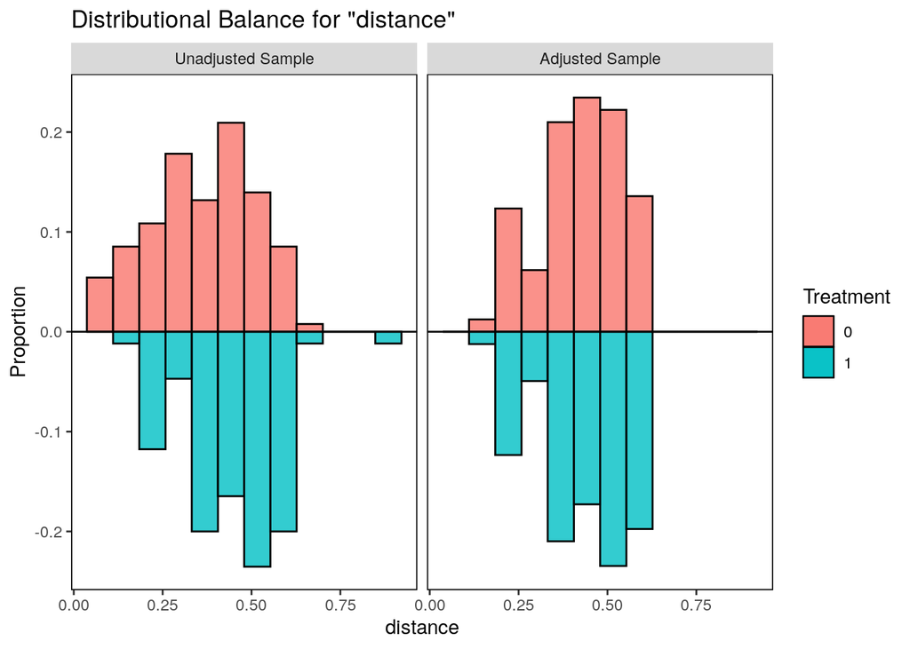

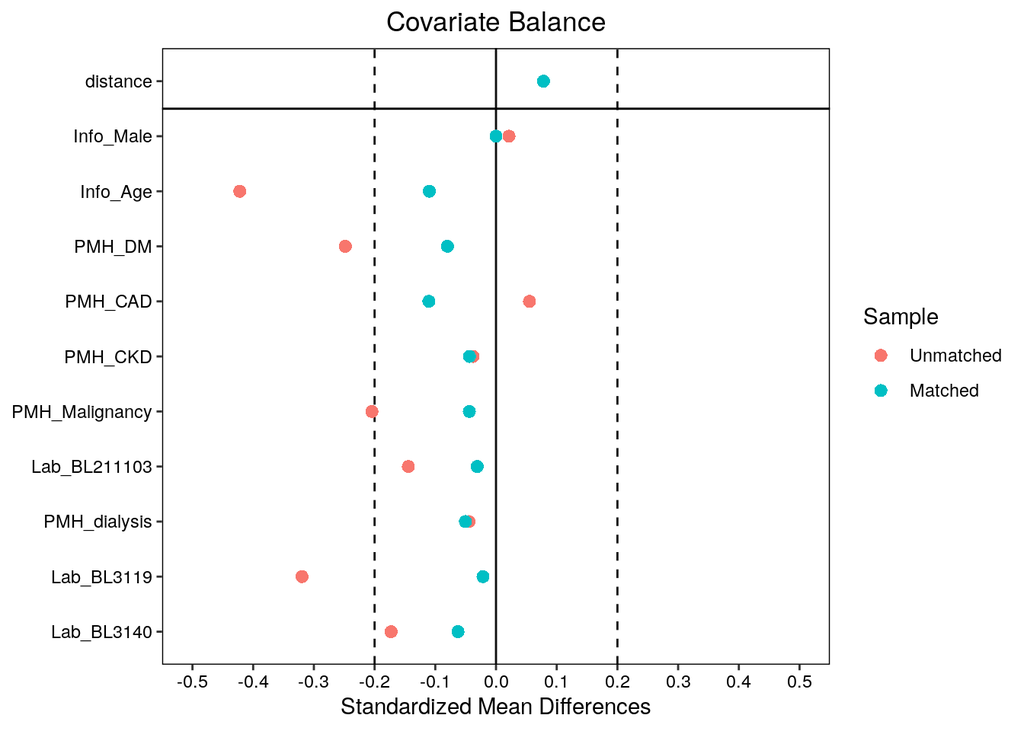

## Tables

### Repair vs. Replacement

#### Baseline Table

Repair

Replacement

Total

p

(N=81)

(N=81)

(N=162)

Male

45 (55.6%)

45 (55.6%)

90 (55.6%)

1.000

Age

43.9 ± 16.1

45.7 ± 16.4

44.8 ± 16.2

0.478

Height

166.7 ± 8.2

165.7 ± 9.0

166.2 ± 8.6

0.448

Weight

58.0 ± 10.6

59.3 ± 11.9

58.6 ± 11.2

0.469

BMI

20.8 ± 3.4

21.5 ± 3.3

21.2 ± 3.3

0.233

Dyspnea

13 (16.0%)

20 (24.7%)

33 (20.4%)

0.242

Fever

71 (87.7%)

68 (84.0%)

139 (85.8%)

0.653

Chillis

40 (49.4%)

37 (45.7%)

77 (47.5%)

0.753

Myalgia

31 (38.3%)

29 (35.8%)

60 (37.0%)

0.871

Fatigue

5 ( 6.2%)

10 (12.3%)

15 ( 9.3%)

0.278

Generalweakness

21 (25.9%)

36 (44.4%)

57 (35.2%)

0.021

Embolism

46 (56.8%)

44 (54.3%)

90 (55.6%)

0.874

Hypertension

16 (19.8%)

19 (23.5%)

35 (21.6%)

0.703

Diabetes

6 ( 7.4%)

8 ( 9.9%)

14 ( 8.6%)

0.780

CAD

3 ( 3.7%)

5 ( 6.2%)

8 ( 4.9%)

0.720

CVA

3 ( 3.7%)

6 ( 7.4%)

9 ( 5.6%)

0.495

CKD

7 ( 8.6%)

8 ( 9.9%)

15 ( 9.3%)

1.000

Dialysis

5 ( 6.2%)

6 ( 7.4%)

11 ( 6.8%)

1.000

Smoking

23 (28.4%)

29 (35.8%)

52 (32.1%)

0.400

Malignancy

5 ( 6.2%)

6 ( 7.4%)

11 ( 6.8%)

1.000

Obesity

8 ( 9.9%)

10 (12.5%)

18 (11.2%)

0.781

PreviousOHS

0 ( 0.0%)

1 ( 1.2%)

1 ( 0.6%)

1.000

Bloodculture(+)

62 (76.5%)

68 (84.0%)

130 (80.2%)

0.324

WBC

9.0 ± 4.7

10.9 ± 5.6

9.9 ± 5.2

0.023

Hemoglobin

10.7 ± 1.6

10.3 ± 1.6

10.5 ± 1.6

0.190

Platelet

247.6 ± 118.3

244.2 ± 105.2

245.9 ± 111.6

0.848

PT (INR)

1.1 ± 0.2

1.1 ± 0.2

1.1 ± 0.2

0.840

Albumin

3.4 ± 0.6

3.2 ± 0.5

3.3 ± 0.6

0.018

Total Bilirubin

0.8 ± 1.0

0.9 ± 1.4

0.8 ± 1.2

0.777

AST

27.3 ± 16.1

56.2 ± 229.7

41.9 ± 163.5

0.262

ALT

28.3 ± 23.9

48.5 ± 143.0

38.5 ± 103.0

0.213

BUN

13.9 ± 10.1

14.2 ± 10.4

14.0 ± 10.2

0.856

Creatinine

1.2 ± 1.4

1.4 ± 2.1

1.3 ± 1.8

0.477

HbA1c

5.7 ± 0.7

5.8 ± 1.0

5.8 ± 0.9

0.546

NT-proBNP

3762.3 ± 9090.3

4323.9 ± 7685.0

4043.1 ± 8385.7

0.718

Segmented neutrophil

71.4 ± 11.4

75.1 ± 10.4

73.3 ± 11.0

0.033

CRP

5.8 ± 6.3

6.2 ± 6.2

6.0 ± 6.2

0.680

Procalcitonin

3.1 ± 6.0

22.9 ± 85.1

12.1 ± 58.0

0.206

Ix_CHF

37 (45.7%)

51 (63.0%)

88 (54.3%)

0.040

Ix_infection

12 (14.8%)

7 ( 8.6%)

19 (11.7%)

0.329

Ix_vegetation

67 (82.7%)

66 (81.5%)

133 (82.1%)

1.000

Onset-to-Surgery duration

23.9 ± 17.8

27.6 ± 27.8

25.8 ± 23.3

0.311

Antibiotics-to-Surgery duration

9.0 ± 10.8

8.2 ± 10.2

8.6 ± 10.5

0.639

prev_MV_Op

- FALSE

81 (100.0%)

81 (100.0%)

162 (100.0%)

MS

0.007

- no

81 (100.0%)

73 (90.1%)

154 (95.1%)

- minimal

0 ( 0.0%)

0 ( 0.0%)

0 ( 0.0%)

- minimal-to-mild

0 ( 0.0%)

0 ( 0.0%)

0 ( 0.0%)

- mild

0 ( 0.0%)

0 ( 0.0%)

0 ( 0.0%)

- mild-to-moderate

0 ( 0.0%)

1 ( 1.2%)

1 ( 0.6%)

- moderate

0 ( 0.0%)

1 ( 1.2%)

1 ( 0.6%)

- moderate-to-severe

0 ( 0.0%)

1 ( 1.2%)

1 ( 0.6%)

- severe

0 ( 0.0%)

5 ( 6.2%)

5 ( 3.1%)

MR

0.306

- no

6 ( 7.4%)

7 ( 8.6%)

13 ( 8.0%)

- minimal

6 ( 7.4%)

2 ( 2.5%)

8 ( 4.9%)

- minimal-to-mild

1 ( 1.2%)

1 ( 1.2%)

2 ( 1.2%)

- mild

12 (14.8%)

6 ( 7.4%)

18 (11.1%)

- mild-to-moderate

4 ( 4.9%)

2 ( 2.5%)

6 ( 3.7%)

- moderate

12 (14.8%)

8 ( 9.9%)

20 (12.3%)

- moderate-to-severe

6 ( 7.4%)

10 (12.3%)

16 ( 9.9%)

- severe

34 (42.0%)

45 (55.6%)

79 (48.8%)

MR>=moderate

52 (64.2%)

63 (77.8%)

115 (71.0%)

0.083

Annularreconstruction

7 ( 8.6%)

18 (22.2%)

25 (15.4%)

0.030

prev_AV_Op

- FALSE

81 (100.0%)

81 (100.0%)

162 (100.0%)

AVIE

5 ( 6.2%)

3 ( 3.7%)

8 ( 4.9%)

0.720

AS

1.000

- no

81 (100.0%)

81 (100.0%)

162 (100.0%)

- minimal

0 ( 0.0%)

0 ( 0.0%)

0 ( 0.0%)

- minimal-to-mild

0 ( 0.0%)

0 ( 0.0%)

0 ( 0.0%)

- mild

0 ( 0.0%)

0 ( 0.0%)

0 ( 0.0%)

- mild-to-moderate

0 ( 0.0%)

0 ( 0.0%)

0 ( 0.0%)

- moderate

0 ( 0.0%)

0 ( 0.0%)

0 ( 0.0%)

- moderate-to-severe

0 ( 0.0%)

0 ( 0.0%)

0 ( 0.0%)

- severe

0 ( 0.0%)

0 ( 0.0%)

0 ( 0.0%)

AR

0.522

- no

76 (93.8%)

79 (97.5%)

155 (95.7%)

- minimal

1 ( 1.2%)

0 ( 0.0%)

1 ( 0.6%)

- minimal-to-mild

0 ( 0.0%)

0 ( 0.0%)

0 ( 0.0%)

- mild

3 ( 3.7%)

2 ( 2.5%)

5 ( 3.1%)

- mild-to-moderate

0 ( 0.0%)

0 ( 0.0%)

0 ( 0.0%)

- moderate

0 ( 0.0%)

0 ( 0.0%)

0 ( 0.0%)

- moderate-to-severe

0 ( 0.0%)

0 ( 0.0%)

0 ( 0.0%)

- severe

1 ( 1.2%)

0 ( 0.0%)

1 ( 0.6%)

AR>=moderate

1 ( 1.2%)

0 ( 0.0%)

1 ( 0.6%)

1.000

ConcomitantAVOp

8 ( 9.9%)

5 ( 6.2%)

13 ( 8.0%)

0.563

prev_TV_Op

- FALSE

81 (100.0%)

81 (100.0%)

162 (100.0%)

TV_IE

2 ( 2.5%)

1 ( 1.2%)

3 ( 1.9%)

1.000

TS

1.000

- no

81 (100.0%)

81 (100.0%)

162 (100.0%)

- minimal

0 ( 0.0%)

0 ( 0.0%)

0 ( 0.0%)

- minimal-to-mild

0 ( 0.0%)

0 ( 0.0%)

0 ( 0.0%)

- mild

0 ( 0.0%)

0 ( 0.0%)

0 ( 0.0%)

- mild-to-moderate

0 ( 0.0%)

0 ( 0.0%)

0 ( 0.0%)

- moderate

0 ( 0.0%)

0 ( 0.0%)

0 ( 0.0%)

- moderate-to-severe

0 ( 0.0%)

0 ( 0.0%)

0 ( 0.0%)

- severe

0 ( 0.0%)

0 ( 0.0%)

0 ( 0.0%)

TR

0.072

- no

76 (93.8%)

66 (81.5%)

142 (87.7%)

- minimal

0 ( 0.0%)

0 ( 0.0%)

0 ( 0.0%)

- minimal-to-mild

1 ( 1.2%)

1 ( 1.2%)

2 ( 1.2%)

- mild

2 ( 2.5%)

2 ( 2.5%)

4 ( 2.5%)

- mild-to-moderate

2 ( 2.5%)

7 ( 8.6%)

9 ( 5.6%)

- moderate

0 ( 0.0%)

4 ( 4.9%)

4 ( 2.5%)

- moderate-to-severe

0 ( 0.0%)

0 ( 0.0%)

0 ( 0.0%)

- severe

0 ( 0.0%)

1 ( 1.2%)

1 ( 0.6%)

TR>=moderate

0 ( 0.0%)

5 ( 6.2%)

5 ( 3.1%)

0.059

ConcomitantTVOp

4 ( 4.9%)

11 (13.6%)

15 ( 9.3%)

0.104

Concomitantprocedure

14 (17.3%)

15 (18.5%)

29 (17.9%)

1.000

CABG

2 ( 2.5%)

6 ( 7.4%)

8 ( 4.9%)

0.277

Maze

0 ( 0.0%)

2 ( 2.5%)

2 ( 1.2%)

0.497

Aorta surgery

- FALSE

81 (100.0%)

81 (100.0%)

162 (100.0%)

CPB time

112.0 ± 55.4

126.9 ± 46.7

119.3 ± 51.7

0.067

ACC time

84.5 ± 46.8

101.0 ± 41.1

92.7 ± 44.7

0.019

Nasal temperature

29.7 ± 1.8

29.2 ± 1.7

29.5 ± 1.8

0.085

Rectal temperature

31.0 ± 1.8

30.7 ± 1.8

30.8 ± 1.8

0.362

Death

8 ( 9.9%)

16 (19.8%)

24 (14.8%)

0.122

Earlymortality

2 ( 2.5%)

1 ( 1.2%)

3 ( 1.9%)

1.000

In-hospitalmortality

2 ( 2.5%)

1 ( 1.2%)

3 ( 1.9%)

1.000

Recurrence

1 ( 1.2%)

3 ( 3.7%)

4 ( 2.5%)

0.620

Reoperationd/trecurrence

1 ( 1.2%)

2 ( 2.5%)

3 ( 1.9%)

1.000

Valve-relatedReopartion

3 ( 3.7%)

3 ( 3.7%)

6 ( 3.7%)

1.000

Bleeding

1 ( 1.2%)

14 (17.3%)

15 ( 9.3%)

0.001

Majorbleeding

1 ( 1.2%)

11 (13.6%)

12 ( 7.4%)

0.007

Minorbleeding

0 ( 0.0%)

3 ( 3.7%)

3 ( 1.9%)

0.245

Thromboembolism

1 ( 1.2%)

2 ( 2.5%)

3 ( 1.9%)

1.000

Majorthromboembolism

1 ( 1.2%)

1 ( 1.2%)

2 ( 1.2%)

1.000

Minorthromboembolism

0 ( 0.0%)

1 ( 1.2%)

1 ( 0.6%)

1.000

#### SMD Table

| variable | smd |
| --- | --- |
| Info_Male | 0.0000 |
| Info_Age | 0.1117 |
| Baseline_Ht | -0.1197 |
| Baseline_Wt | 0.1143 |
| Baseline_BMI | 0.1888 |
| Symptom_dyspnea | -0.2158 |
| Symptom_fever | -0.1063 |
| Symptom_chills | -0.0742 |
| Symptom_myalgia | -0.0511 |
| Symptom_fatigue | -0.2142 |
| Symptom_GW | 0.3953 |
| IE_embolism | 0.0497 |
| PMH_HTN | -0.0901 |
| PMH_DM | -0.0880 |
| PMH_CAD | -0.1141 |
| PMH_CVA | -0.1622 |
| PMH_CKD | -0.0426 |
| PMH_dialysis | -0.0491 |
| PMH_Smoking | 0.1592 |
| PMH_Malignancy | -0.0491 |
| PMH_Obesity | NA |
| PMH_prev.OHS | -0.1581 |
| IE_culture | 0.1869 |
| Lab_BL2011 | 0.3616 |
| Lab_BL2013 | -0.2069 |
| Lab_BL2016 | -0.0302 |
| Lab_BL211103 | 0.0318 |
| Lab_BL3112 | -0.3768 |
| Lab_BL3114 | 0.0448 |
| Lab_BL3115 | 0.1774 |
| Lab_BL3116 | 0.1973 |
| Lab_BL3119 | 0.0285 |
| Lab_BL3120 | 0.1122 |
| Lab_BL3164 | 0.1317 |
| Lab_BL3982 | 0.0667 |
| Lab_BL201806 | 0.3384 |
| Lab_BL3140 | 0.0650 |
| Lab_BL5044 | 0.3279 |
| Op_Ix_HF | 0.3523 |
| Op_Ix_uncontrolled_infection | 0.1927 |
| Op_Ix_Embolism_vegetation | 0.0322 |
| Duration_Onset2Op | 0.1597 |
| Duration_Anti2Op | -0.0739 |
| Mitral_prev_MV_Op | NA |
| Mitral_MS | NA |
| Mitral_MR | NA |
| MR_gr_mod | 0.3027 |
| Mitral_annular_recon | -0.3827 |
| Aortic_Prev_AV_Op | NA |
| Aortic_IE_lesion | 0.1141 |
| Aortic_AS | NA |
| Aortic_AR | NA |
| AR_gr_mod | 0.1581 |
| Aortic_Concomittant_AV_Op | 0.1366 |
| Tricuspid_Prev_TV_Op | NA |
| Tricuspid_IE_lesion | 0.0917 |
| Tricuspid_TS | NA |
| Tricuspid_TR | NA |
| TR_gr_mod | 0.3627 |
| Tricuspid_Concomittant_TV_Op | 0.3015 |
| Concomitant_other_procedure | -0.0322 |
| Concomitant_CABG | -0.2294 |
| Concomitant_maze | -0.2250 |
| Concomitant_aorta | NA |
| CPB_CPB_time | 0.2923 |
| CPB_ACC_time | 0.3754 |
| CPB_N_BT | -0.2731 |
| CPB_R_BT | -0.1455 |
| O_Survival_Death | -0.2807 |
| O_Survival_EM | 0.0917 |
| O_Survival_IHM | 0.0917 |
| O_Recurrence_Recur | -0.1596 |
| O_Recurrence_ReOp | -0.0917 |
| O_Valve_ReOp | 0.0000 |
| O_Valve_Bleeding | -0.5762 |
| O_Valve_B_major | -0.4851 |
| O_Valve_B_minor | -0.2774 |
| O_Valve_Embolism | -0.0917 |
| O_Valve_E_major | 0.0000 |
| O_Valve_E_minor | -0.1581 |

## Figures

### Survival - Repair vs. Replacment

Median follow up duration : 55.56 months

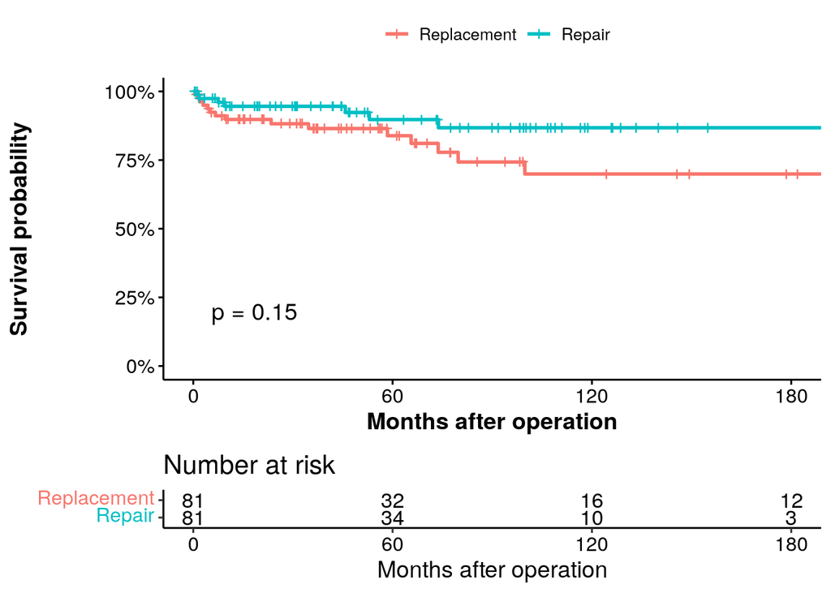

| strata | Month 60 | Month 120 | Month 180 |
| --- | --- | --- | --- |
| Overall | 86.8 ± 3.1 % | 78.5 ± 4.6 % | 78.5 ± 4.6 % |
| strata=FALSE | 83.9 ± 4.7 % | 69.9 ± 7.6 % | 69.9 ± 7.6 % |
| strata=TRUE | 89.8 ± 4.2 % | 86.8 ± 5.0 % | 86.8 ± 5.0 % |

### Composite Endpoint - Repair vs. Replacment

Median follow up duration : 55.49 months

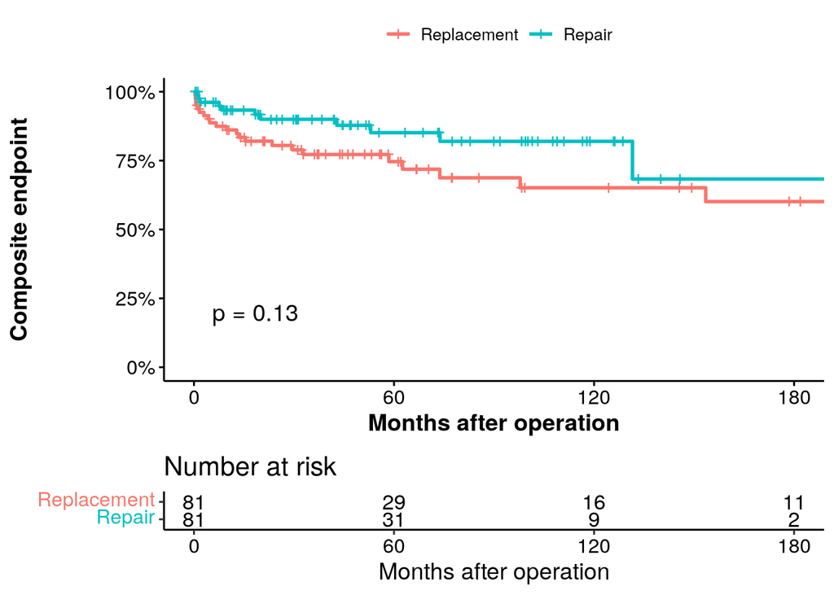

| strata | Month 60 | Month 120 | Month 180 |
| --- | --- | --- | --- |
| Overall | 79.7 ± 3.6 % | 73.3 ± 4.6 % | 65.2 ± 6.8 % |
| strata=FALSE | 74.6 ± 5.4 % | 65.1 ± 7.0 % | 60.1 ± 8.1 % |
| strata=TRUE | 85.1 ± 4.8 % | 82.0 ± 5.6 % | 68.3 ± 13.3 % |